# Multiplicative input noise infusion

Lars Vilhuber

First proposed by [Evans, Zayatz and Slanta (1998)](http://www.jos.nu/Articles/abstract.asp?article=144537), multiplicative input noise infusion (henceforth simply “noise infusion”) is used as a disclosure-avoidance measure. See also [our implementation](https://ideas.repec.org/h/nbr/nberch/0485.html) in the [Quarterly Workforce Indicators](http://lehd.ces.census.gov/data) (published in 2009, but first implemented in 2003).

This repository illustrates noise infusion with some toy data. Please feel free [to fork it](https://github.com/labordynamicsinstitute/rampnoise/) and play with it.

# Creating toy data

Let’s generate some random data:

```r
employment <- round(as.data.frame(exp(runif(size,log(1),log(42000)))))
names(employment) <- c("Count")
```

This fake employment distribution looks like this (actually, real employment is different):

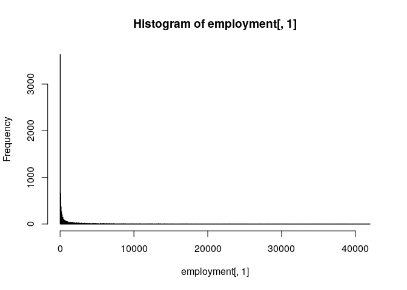

or for a closeup:

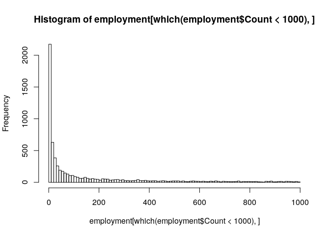

but most importantly, it has a **mean of 3879**, a **median of 215**, and **Q25 of 15**.